# The Relationship Between Income and Life Expectancy

Echefu Chinwendu

2024-02-28

# 1 Introduction

Four datasets from the World Life Expectancy data - Income per Person, Life Expectancy, Population Size and Country Regions, contain information that potentially impacts the life expectancy of the world. The data covers relative information between 1800 and 2018. All four datasets were combined together into one dataset for this analysis.

# 2 Datasets

A brief description and analysis of each dataset is given below.

## 2.1 Income per person

According to the information obtained from `gapminder.org`, this dataset shows the mean daily household per capita income or consumption expenditure expressed in 2017 PPP (constant international dollars). There are 220 variables and 193 observations. The rows are the different countries in the world while the columns (with the exception of the first) are the years from 1800 to 2018. The first 10 columns and first 5 rows are shown below.

```r
dat1 <- read.csv(file = "https://github.com/chinwex/STA553/raw/main/w05/income_per_person.csv")
kable(dat1[1:5, 1:10])
```

| geo | X1800 | X1801 | X1802 | X1803 | X1804 | X1805 | X1806 | X1807 | X1808 |
| --- | --- | --- | --- | --- | --- | --- | --- | --- | --- |
| Afghanistan | 603 | 603 | 603 | 603 | 603 | 603 | 603 | 603 | 603 |
| Albania | 667 | 667 | 667 | 667 | 667 | 668 | 668 | 668 | 668 |
| Algeria | 715 | 716 | 717 | 718 | 719 | 720 | 721 | 722 | 723 |
| Andorra | 1200 | 1200 | 1200 | 1200 | 1210 | 1210 | 1210 | 1210 | 1220 |
| Angola | 618 | 620 | 623 | 626 | 628 | 631 | 634 | 637 | 640 |

The dataset was then reshaped to make a longitudinal data such that the resulting data set has three columns: country, year, and income. The new dataset has 42,267 observations.

```r
dat1.long <- dat1 %>%
  gather(key = "Year", value = "income", - geo, na.rm = TRUE)
colnames(dat1.long)[1] <- "country"
kable(head(dat1.long))
```

| country | Year | income |
| --- | --- | --- |
| Afghanistan | X1800 | 603 |
| Albania | X1800 | 667 |
| Algeria | X1800 | 715 |
| Andorra | X1800 | 1200 |
| Angola | X1800 | 618 |
| Antigua and Barbuda | X1800 | 757 |

## 2.2 Life Expectancy in Years

This dataset shows the number of years a newborn infant would live if the current mortality rates at different ages were to stay the same throughout its life. It has 220 variables and 187 observations. The observations are countries and the variables (with the exception of the first) are the different years (source - `gapminder.org`)

```r
dat2 <- read.csv(file="https://github.com/chinwex/STA553/raw/main/w05/life_expectancy_years.csv")
kable(dat2[1:5, 1:10])
```

| geo | X1800 | X1801 | X1802 | X1803 | X1804 | X1805 | X1806 | X1807 | X1808 |
| --- | --- | --- | --- | --- | --- | --- | --- | --- | --- |
| Afghanistan | 28.2 | 28.2 | 28.2 | 28.2 | 28.2 | 28.2 | 28.1 | 28.1 | 28.1 |
| Albania | 35.4 | 35.4 | 35.4 | 35.4 | 35.4 | 35.4 | 35.4 | 35.4 | 35.4 |
| Algeria | 28.8 | 28.8 | 28.8 | 28.8 | 28.8 | 28.8 | 28.8 | 28.8 | 28.8 |
| Andorra | NA | NA | NA | NA | NA | NA | NA | NA | NA |
| Angola | 27.0 | 27.0 | 27.0 | 27.0 | 27.0 | 27.0 | 27.0 | 27.0 | 27.0 |

The dataset was reshaped to make a longitudinal data such that the resulting data set has three columns: country, year, and Life Expectancy. There are 40,437 observations in the new data.

```r
dat2.long <- dat2 %>%
  gather(key = "Year", value = "Life_Expectancy", - geo, na.rm = TRUE)
colnames(dat2.long)[1] <- "country"
kable(head(dat2.long))
```

|  | country | Year | Life_Expectancy |
| --- | --- | --- | --- |
| 1 | Afghanistan | X1800 | 28.2 |
| 2 | Albania | X1800 | 35.4 |
| 3 | Algeria | X1800 | 28.8 |
| 5 | Angola | X1800 | 27.0 |
| 6 | Antigua and Barbuda | X1800 | 33.5 |
| 7 | Argentina | X1800 | 33.2 |

## 2.3 Country Regions

This contains data on countries and the various regions they belong to. There are 5 regions and they include: Asia (51 countries), Europe(51 countries), Africa(59 countries), Americas (57 countries), and Oceania (29 countries). The table below shows 4 (most important) out of the 11 variables in the dataset.

```r
dat3 <- read.csv(file="https://github.com/chinwex/STA553/raw/main/w05/countries_total.csv")
kable(head(dat3[c(1,3,4,5,6,7), c(1,3,6,7)]))       # Excluded the second country in the dataset because it contains invalid characters.
```

|  | name | alpha.3 | region | sub.region |
| --- | --- | --- | --- | --- |
| 1 | Afghanistan | AFG | Asia | Southern Asia |
| 3 | Albania | ALB | Europe | Southern Europe |
| 4 | Algeria | DZA | Africa | Northern Africa |
| 5 | American Samoa | ASM | Oceania | Polynesia |
| 6 | Andorra | AND | Europe | Southern Europe |
| 7 | Angola | AGO | Africa | Sub-Saharan Africa |

## 2.4 Population Size

This data shows the population counts of the number of people living in the country. It contains population information from 1800 to 2018 for 195 countries.

```r
dat4 <- read.csv(file="https://github.com/chinwex/STA553/raw/main/w05/population_total.csv")
kable(dat4[1:5, 1:10])
```

| geo | X1800 | X1801 | X1802 | X1803 | X1804 | X1805 | X1806 | X1807 | X1808 |
| --- | --- | --- | --- | --- | --- | --- | --- | --- | --- |
| Afghanistan | 3280000 | 3280000 | 3280000 | 3280000 | 3280000 | 3280000 | 3280000 | 3280000 | 3280000 |
| Albania | 410000 | 412000 | 413000 | 414000 | 416000 | 417000 | 418000 | 420000 | 421000 |
| Algeria | 2500000 | 2510000 | 2520000 | 2530000 | 2540000 | 2550000 | 2560000 | 2570000 | 2580000 |
| Andorra | 2650 | 2650 | 2650 | 2650 | 2650 | 2650 | 2650 | 2650 | 2650 |
| Angola | 1570000 | 1570000 | 1570000 | 1570000 | 1570000 | 1570000 | 1570000 | 1570000 | 1570000 |

The dataset was reshaped to make a longitudinal data such that the resulting data set has three columns: country, year, and population size. The new dataset has 42,705 observations.

```r
dat4.long <- dat4 %>%
  gather(key = "Year", value = "Population_size", - geo, na.rm = TRUE)
colnames(dat4.long)[1] <- "country"
kable(head(dat4.long))
```

| country | Year | Population_size |
| --- | --- | --- |
| Afghanistan | X1800 | 3280000 |
| Albania | X1800 | 410000 |
| Algeria | X1800 | 2500000 |
| Andorra | X1800 | 2650 |
| Angola | X1800 | 1570000 |
| Antigua and Barbuda | X1800 | 37000 |

# 3 Merging Datasets

All 4 datasets were combined together to get one dataset used for analysis.

## 3.1 Income and Life Expectancy

Two longitudinal data sets (income and life expectancy with 3 variables each) were merged together to make a new data set, `LifeExpIncom`, that has 4 variables: country, year, lifeExp, and income. The new dataset has 40,437 observations.

```r
LifeExpIncom = inner_join(dat1.long, dat2.long, by = c("country", "Year"))
kable(head(LifeExpIncom))
```

| country | Year | income | Life_Expectancy |
| --- | --- | --- | --- |
| Afghanistan | X1800 | 603 | 28.2 |
| Albania | X1800 | 667 | 35.4 |
| Algeria | X1800 | 715 | 28.8 |
| Angola | X1800 | 618 | 27.0 |
| Antigua and Barbuda | X1800 | 757 | 33.5 |
| Argentina | X1800 | 1510 | 33.2 |

## 3.2 Income, Life Expectancy and Country Regions

```r
dat3.new = dat3
dat3.new$country = dat3$name          # name variable changed to country in the regions dataset.
dat3.new = dat3.new[,-1]

## data corrections in the regions dataset
dat3.new[dat3.new == "Bolivia (Plurinational State of)"] <- "Bolivia"
dat3.new[dat3.new == "Brunei Darussalam"] <- "Brunei"
dat3.new[dat3.new == "Cabo Verde"] <- "Cape Verde"
dat3.new[dat3.new == "Kyrgyzstan"] <- "Kazakhstan"
dat3.new[dat3.new == "Macedonia (the former Yugoslav Republic of)"] <- "Macedonia, FYR"
dat3.new[dat3.new == "Micronesia (Federated States of)"] <- "Micronesia, Fed. Sts."
dat3.new[dat3.new == "Viet Nam"] <- "Vietnam"
dat3.new[dat3.new == "Lao "] <- "Lao"
dat3.new[dat3.new == "Iran "] <- "Iran"
dat3.new[dat3.new == "Moldova "] <- "Moldova"
```

On further examination of the country regions dataset, some data entry errors were found and corrected:

1. “Bolivia” in **country region** dataset was recorded as “Bolivia(Plurinational state of). This was corrected as just **Bolivia** to aviod loss of data during merging.
2. “Brunei” in **country region** dataset was recorded as “Brunei Darussalam”. This was corrected to **Brunei**
3. “Cape Verde” in **country region** dataset was recorded as “Cabo Verde”. This was corrected to **Cape verde**
4. “Kazakhstan” in **country region** dataset was recorded as “kyrgyzstan”, which is same as “Kyrgyz Republic” in the dataset. This was corrected to **Kazakhstan**
5. “Macedonia, FYR” in **country region** dataset was recorded as “Macedonia (the former Yugoslav Republic of)”. This was corrected to **Macedonia, FYR**
6. “Micronesia, Fed. Sts.” in **country region** dataset was recorded as “Micronesia (Federated States of)”. This was corrected to **Micronesia, Fed. Sts.**
7. “Vietnam” in **country region** dataset was recorded as “Viet Nam”. This was corrected to **Vietnam**
8. “Lao” in **country region** dataset was recorded as “Lao” (contains an extra space). This was corrected to **Lao**
9. “Iran” in **country region** dataset was recorded as “Iran” (contains an extra space). This was corrected to **Iran**

Then, the data was combined with the previously merged data of Income and Life Expectancy to get 5 variables (Country, Region, Year, Income and Life Expectancy) and 40,437 observations.

```r
dat3.newsub <- dat3.new[,c(5,11)]
final1 = left_join(LifeExpIncom, dat3.newsub, by = "country")
kable(head(final1))
```

| country | Year | income | Life_Expectancy | region |
| --- | --- | --- | --- | --- |
| Afghanistan | X1800 | 603 | 28.2 | Asia |
| Albania | X1800 | 667 | 35.4 | Europe |
| Algeria | X1800 | 715 | 28.8 | Africa |
| Angola | X1800 | 618 | 27.0 | Africa |
| Antigua and Barbuda | X1800 | 757 | 33.5 | Americas |
| Argentina | X1800 | 1510 | 33.2 | Americas |

Countries like Swaziland, Congo Rep and Turkmenistan were not in the Country Regions dataset. But their regions are known:

1. Swaziland = Africa
2. Congo Rep = Africa
3. Turkmenistan = Asia

Therefore, these were added to the dataset.

```r
final1$region[is.na(final1$region)] <- c("Africa", "Africa", "Asia")
```

## 3.3 Income, Life Expectancy, Country Regions and Population Size

The previous resulting data set was merged together with population size longitudinal data to create a new data set that has 6 variables: country, year, life Expectancy, income, region and population size. The total number of observations was 40,437.

```r
final2 = inner_join(final1, dat4.long, by = c("country", "Year"))
kable(head(final2))
```

| country | Year | income | Life_Expectancy | region | Population_size |
| --- | --- | --- | --- | --- | --- |
| Afghanistan | X1800 | 603 | 28.2 | Asia | 3280000 |
| Albania | X1800 | 667 | 35.4 | Europe | 410000 |
| Algeria | X1800 | 715 | 28.8 | Africa | 2500000 |
| Angola | X1800 | 618 | 27.0 | Africa | 1570000 |
| Antigua and Barbuda | X1800 | 757 | 33.5 | Americas | 37000 |
| Argentina | X1800 | 1510 | 33.2 | Americas | 534000 |

# 4 Merged (Complete) Dataset

The X in the variable “Year” was then removed and the order of variables rearranged.

```r
final.data = final2[,-2]
final.data$year = substr((final2$Year), 2, 5)

final.data <- final.data[, c(1, 4, 6, 2, 3, 5)]
kable(head(final.data))
```

| country | region | year | income | Life_Expectancy | Population_size |
| --- | --- | --- | --- | --- | --- |
| Afghanistan | Asia | 1800 | 603 | 28.2 | 3280000 |
| Albania | Europe | 1800 | 667 | 35.4 | 410000 |
| Algeria | Africa | 1800 | 715 | 28.8 | 2500000 |
| Angola | Africa | 1800 | 618 | 27.0 | 1570000 |
| Antigua and Barbuda | Americas | 1800 | 757 | 33.5 | 37000 |
| Argentina | Americas | 1800 | 1510 | 33.2 | 534000 |

The dataset contains 40437 observations and 6 variables. The variables are:

1. `country` - Name of the country (categorical)
2. `Region` - The region the country belongs to (categorical)
3. `Year` - Year (categorical)
4. `Income` - Income (Numerical)
5. `life expectancy` - Number of years (Numerical)
6. `Population Size` - Total Population count of a country (Numerical)

A copy of the final merged dataset can be found here: https://github.com/chinwex/STA553/raw/main/w05/merged_data.csv

```r
## saved the new dataset to a local drive
write.csv(final.data, "C:\\Users\\echef\\Documents\\STA553\\Week 5\\merged_data.csv")
```

# 5 Subset of the Data for Analysis

A subset of the data containing only data for the year 2000 was created and called `2000data` The data contains 6 variables (country, region, year, income, life expectancy and population size) and 187 observations

```r
`2000data` <- filter(final.data, year == 2000)
kable(head(`2000data`))
```

| country | region | year | income | Life_Expectancy | Population_size |
| --- | --- | --- | --- | --- | --- |
| Afghanistan | Asia | 2000 | 972 | 51.6 | 20100000 |
| Albania | Europe | 2000 | 5470 | 74.4 | 3120000 |
| Algeria | Africa | 2000 | 10200 | 73.9 | 31200000 |
| Andorra | Europe | 2000 | 31700 | 81.8 | 65400 |
| Angola | Africa | 2000 | 3510 | 53.4 | 16400000 |
| Antigua and Barbuda | Americas | 2000 | 18800 | 74.7 | 83600 |

# 6 Plot of the Data

```r
plot.theme <- function() {
  theme(
    plot.title = element_text(face = "bold",
                              size = 12,
                              family = "sans",
                              color = "#009E73",
                              hjust = 0.5),
    # add border 1)
    panel.border = element_rect(colour = "#009E73",
                                fill = NA,
                                linetype = 2),
    # color background 2)
   # panel.background = element_rect(fill = "#F0E442"),
    # modify grid 3)
    panel.grid.major.x = element_line(colour = "#56B4E9",
                                      linetype = 3,
                                      size = 0.5),
    panel.grid.minor.x = element_blank(),
    panel.grid.major.y =  element_line(colour = "#56B4E9",
                                       linetype = 3,
                                       size = 0.5),
    panel.grid.minor.y = element_blank(),

    axis.text = element_text(colour = "#56B4E9",
                             face = "italic",
                             family = "Times New Roman"),
    axis.title = element_text(colour = "#0072B2",
                              family = "Times New Roman"),
    axis.ticks = element_line(colour = "#56B4E9"))
}
```

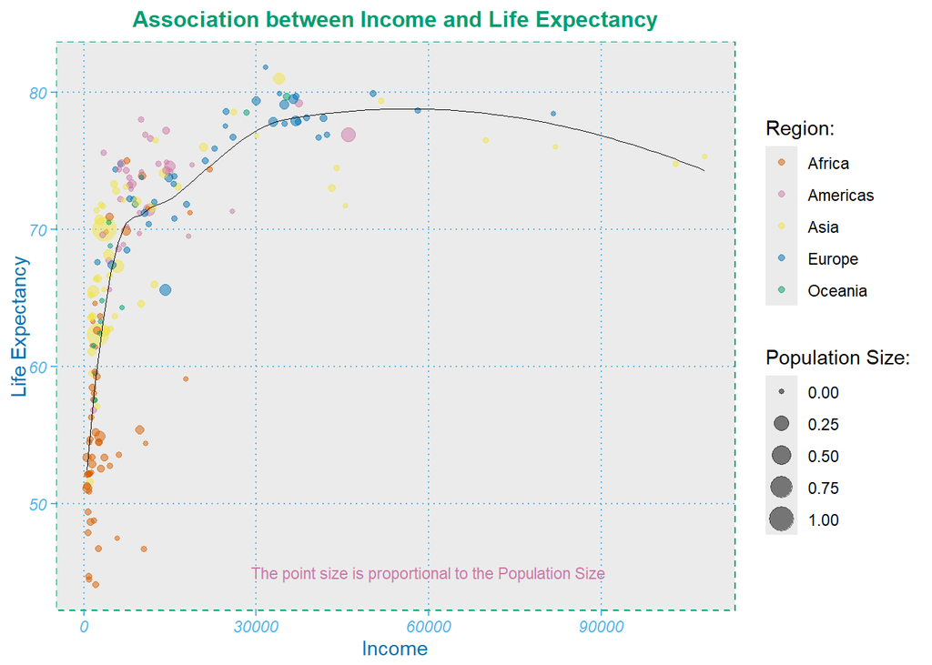

Scatter Plot Showing Income and Life Expectancy

```r
# standardize population size between 0 and 1
pop.size <- `2000data`$Population_size
sizes <- (pop.size - min(pop.size))/(max(pop.size) - min(pop.size))

plot1 <- ggplot(`2000data`, aes(x = income, y = Life_Expectancy,
                              size = sizes)) +
  geom_point(aes(color=region), alpha = 0.5) +
  geom_smooth(method = "loess", se = FALSE, color = "#000000", size = 0.3) +
  scale_color_manual(values=c("#D55E00", "#CC79A7", "#F0E442", "#0072B2", "#009E73")) +
  labs(x = "Income",
       y = "Life Expectancy",
       size = "Population Size:",
       color = "Region:",
       title = "Association between Income and Life Expectancy") +
  plot.theme()  +
  ggplot2::annotate(geom="text" ,
                       x=60000,
                       y=45,
                       label="The point size is proportional to the Population Size",
                          color = "#CC79A7",
                       hjust=0.5,
                    cex=3)


plot_grid(plot1)
```

## 6.1 Plot Interpretation

This is a scatterplot of income and life expectancy for 187 countries in the world for the year 2000. The points on the plot are colored based on their regions (Africa, Americas, Asia, Europe and Oceania). The point sizes are proportional to the population size of each country. There appears to be a curvilinear relationship between income and life expectancy. The first part is linear and then gradually it becomes curved.